# Data Science Consulting: Midterm Team Project Parts 2,3,4

# Part 2: Additional Analyses

## Q1 Preferred Model

**For your preferred model, what is the level of accuracy (percentage of testing cases correctly classified) in each type of product listed in the label variable?**

Our preferred model

We are proposing two options:  
if clients require a quicker calculation speed; then, Random Forest with parameter tuning is the preferred model. If clients prefer more accurate results; then, SVM model is the best option. The level of accuracy in each type of product is listed below.

Overall, both models were best at identifying items with a unique shape; such as, bags, trousers and ankle boots but rather poor at identifying objects with generic shape such as shirts and pullovers.

```
The RF model is overall82.65% accurate.
```

```
The RF model The level of accuracy in each type of product :
```

```
        Bag     Trouser      Sandal  Ankle boot       Dress     Sneaker
      0.952       0.926       0.907       0.903       0.880       0.847
       Coat T-shirt/top    Pullover       Shirt
      0.806       0.779       0.704       0.561
```

```
Support Vector Machines with Radial Basis Function Kernel

5000 samples
  49 predictor
  10 classes: 'Ankle boot', 'Bag', 'Coat', 'Dress', 'Pullover', 'Sandal', 'Shirt', 'Sneaker', 'T-shirt/top', 'Trouser'

No pre-processing
Resampling: Cross-Validated (5 fold)
Summary of sample sizes: 4000, 4000, 4000, 4000, 4000
Resampling results across tuning parameters:

  C   Accuracy  Kappa
   1  0.8108    0.7897778
   3  0.8274    0.8082222
   5  0.8364    0.8182222
  10  0.8448    0.8275556

Tuning parameter 'sigma' was held constant at a value of 0.01
Accuracy was used to select the optimal model using the largest value.
The final values used for the model were sigma = 0.01 and C = 10.
```

```
The SVM model is overall84.33% accurate.
```

```
The SVM model The level of accuracy in each type of product :
```

```
        Bag     Trouser  Ankle boot      Sandal     Sneaker       Dress
      0.959       0.957       0.937       0.916       0.916       0.875
       Coat T-shirt/top    Pullover       Shirt
      0.814       0.793       0.740       0.526
```

## Q2 Additional Question

**Do you think the formula for the Points provides the best trade-off between sample size, running time, and accuracy? How would you revise it based on the experiments you ran?**

The current formula provides a trade-off between sample size, running time, and accuracy. However, it is under discussion on whether it provides the best trade-off. It depends on the clients’ need on what’s their major concern for this type of work. Do they have enough images for each category to predict, how fast they expect to get the model results and what are their minimum requirements/expectations for accuracy.

Additional test should be performed in order to optimize the training data size. The amount of data needed depends both on the complexity of the problem and the chosen algorithm. Most of the models we chose show that with a sample size increase from 1000 to 5000, the total points are lower to some extend. We will choose additional n.values between 1000- 5000, 5000-20000. Then, evaluate dataset size vs Model Skill by setting up an elastic check. Plotting the result as a line plot with training dataset size on the x-axis and model skill on the y-axis to get an idea of how the size of the data affects the skill of the model throughout each training. If the model accuracy has not significantly improved from the previous run, we should perform early stops that halts training. Utilizing both the model checkpoint and early stopping method will maximize accuracy without losing points caused by the sample size simultaneously. In the meantime, finding an optimized training data size can also help minimizing computational time.

## Q3 Addtional Question

**Our client would like to do this work on a larger catalog of images. For now, we will continue to think of this in terms of a collection of 10 labeled images. What kind of processing would be required to scale this model to 1000 such collections? Would this larger problem change your priorities when it comes to sample size, running time, and accuracy?**

Yes, a larger collecting will have different computational needs. We currently use 5000 observation to build the model. When the scale of the model changes to 1000 records in the Training data; there might be too few records to build the models for each collections if we want to build a universe model. The more records we need for each category, the larger the sample size, thus the running time and accuracy of the model will be affected.  
To shorten the long running time, we may preprocess the data first.Then, pre-categorized the images and build sub-models for different categories. Subsequently, select samples from each different sub-groups. In consequence, this can effectively reduce the running time. Additionally, conducting feature selection or PCA analysis to reduce the dimension. Finally, we could consider a combination of different methodology/models to increase the accuracy and lower the computational time.

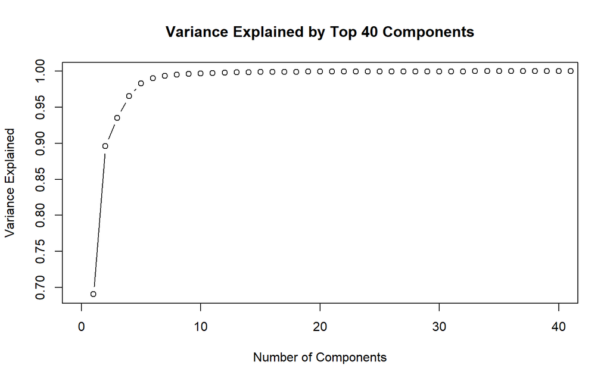

# Part 3: Opportunities

## Q1 Opportunities

**What are some opportunities to learn valuable information and inform strategic decisions? List a number of questions that you might explore.**

In addition to the clothing labels, there is an opportunity to learn more information when collecting pictures. For example:

-Is the picture men’s or women’s wear?  
-Which clothing brands does the picture belong to?

Furthermore, exploring the data further can provide actionable insights which could be used to help classify images in the future. The answers to the following questions can yield valuable information:

-Are there any similarities in the pixels of the clothes with the same brand, like the similar pattern? -What are the top pixels that are most likely to decide the products’ label?  
-What’s the impact from condensing this data from 28 * 28 to 7* 7 pixels?  
-Whether this type of classification method can be extended to colored image? What’s their prediction accuracy?  
-Whether this type of classification method can be extended to real picture? What’s their prediction accuracy?  
-Whether this type of classification method can be extended to video image?

These questions can also drive the strategy regarding storage needs and the requirements for these images from a creative standpoint. For example, knowing the impact of additional pixels on the predictions can change how the Marketing team decides to shoot and store images of the clothing items. Therefore, the algorithms developed have a great way to influence the Marketing function.

## Q2 Products

**What kind of products could be built that would make use of the classification models you constructed? How would they help the client, and how would they help the client’s customers?**

The classification models will be useful to categorize different types of image. As long as they can be divided and condensed into 49 pixels (7 by 7), it will be applicable to the model we built. with the increasing popularity of b2b and b2c platform, image classification will be powerful in the eCommerce area. Classification models can help automatically create tags, organise and visually searches content by labeling features of the image.  
With more accurate categorization Clients’ customers can find the products they need more clearly and easily with different filters and labels. The business side can also use this type of model to better know customers’ interests by collecting and understanding the information of each product they viewed more clarity, by defining each product by its images. this could also be helpful to future targeting/ promotional strategy.

## Q3 Decision makers & Approaches

**How would you approach other decision makers within the organization to assess their priorities and help them better utilize the available information?**

First, we need to report the results of the code and explain them so that both technical and non-technical customers can understand. In addition, we will visualize the data so that the customer can understand it more clearly and in a simpler way.

Furthermore, through the results of data analysis and further data mining, we need to find and summarize the features of the products or the existing problems. For example, are there any similarities in the pixel of the clothing items with the same brand? Do they have similar patterns? Are there some categories that are difficult to distinguish? Then, we can find appropriate departments and decision makers in the client’s company who might meet this kind of problem and who are responsible for solving the corresponding problems to explain the situations by showing them specific analysis reports, charts and so on. Meanwhile, we will keep abreast of their current problems and situation.

Then, we can set priorities for tasks, putting the most influential or difficult issues first. In addition, we need to constantly monitor all kinds of data, collecting more data and information on products’ images and get more features of products. Consequenlty, we need to constantly optimize our model to make accurate predictions on the factors that could decide products’ labels, brands or other features. Thus, we could provide more accurate and effective suggestions. Moreover, communication is also very important when handling clients. After identifying problems, we will timely communicate with our clients to seek solutions.

# Part 4: Internal Wrap-Up

## Q1 Staffing

**What level of staffing would be appropriate for a similar engagement in the future? Tell us how many consultants, the overall weeks, and the number of hours that would be required.**`

The team had 4 part-time consultants working for two weeks. Four consultants for a week working full-time is appropriate for this engagement or the equivalent of 160 working hours. The overall assignment was divided by the models that needed to be created; so everyone could hone their Coding skills.

**The number of people on staff :** 4

**Staff distribution:** Two consultants created three different models. Two created two different models and the functions.

**Skills and competencies within the workforce:** Coders and a Team Managers.

## Q2 Prospective Clients

**What is the best way to pitch this kind of work to other prospective clients? Should we focus on developing the models, training the clients in machine learning, reporting, or perhaps something else?**

The approach will depend on the scope of the assignment and the requirements defined by the client. Every client’s needs are different. The first step would be to define what the client’s needs are; then, tailor the offering to what the client is requiring. Some clients may have employees who have the skill-set necessary to learn Machine Learning along with the bandwidth to learn. Another client may be in need of getting someone to build their machine learning algorithms quickly for a specific project. Each situation requires a different pitch. It may also require different consultants as not everyone who can develop algorithms is capable of conducting Training.

## Q3 Training for Consultants

**What kind of training should we provide to our consultants to be able to do the kind of work you performed?**

The consultants needed for this project need to be well versed in the theory behind every model available for Machine Learning. Writing code just to write code is not efficient. Someone who understand the opportunities and limitations of each potential model. Additionally, a clear understanding of Research Methods and Model Evaluation Methodology is helpful when developing models and making predictions.Subsequently, consultants need to be familiar with creating Baseline Models, Knowledge of Tuning processes to maximize a model’s performance without overfitting or creating too high of a variance is necessary. Consultants should be familiar with how to select the appropriate parameters.